# Trabalho 4 - Aprendizado de Máquina

Aluno: Aíquis Rodrigues Gomes - aiquis.gomes@eic.cefet-rj.br

Orientador: Kele Teixeira Belloze kele.belloze@cefet-rj.br

Professor: Eduardo Bezerra

## O que será apresentado?

O trabalho 4 da disciplina de Aprendizado de Máquina tem como objetivo o aprofundamento dos conhecimentos sobre redes neurais artificiais e redes convolucionais. O trabalho é dividido em duas partes, onde a primeira tem foco no desenvolvimento de uma rede neural completamente conectada (*fully connected*) e a segunda parte demanda a construção de uma rede convolucional.

## Parte 1 - Redes Completamente Conectadas

Na primeira parte do trabalho devemos modelar uma rede neural completamente conectada para prever se um cliente que solicitou empréstimo a uma determinada instiuição financeira irá honrar sua dívida. Para isso temos um conjunto de dados com 1500 exemplos de treinamento e 11 características (*features*) e uma coluna categórica que classifica se aquele cliente pagou ou não sua dívida. O esquema do nosso conjunto de dados é esse:

[figure not shown]

Nossa primeira ação será ler os conjuntos de dados de treinamento e validação e separá-los em vetores X e y, onde X é o vetor de *features* e y é o nosso vetor alvo (*target array*).

```python
import pandas as pd
import numpy as np

# Carregando o conjunto de dados de treinamento
dataset = pd.read_csv('credtrain.txt', names=['ESCT', 'NDEP', 'RENDA',
                      'TIPOR', 'VBEM', 'NPARC', 'VPARC', 'TEL', 'IDADE',
                      'RESMS', 'ENTRADA', 'CLASSE'], sep='\t')

# Criando o vetor X de features com as features do conjunto de dados
X_train = np.array(dataset[['ESCT', 'NDEP', 'RENDA',
                            'TIPOR', 'VBEM', 'NPARC', 'VPARC', 'TEL',
                            'IDADE', 'RESMS', 'ENTRADA']])

# Criando o vetor de classificação y do conjunto de dados de treinamento
y_train = np.array(dataset['CLASSE']).reshape(-1, 1)

# Checando se os formatos estão de acordo com os pedidos no enunciado
# Os formatos devem ser: X = (1500, 11), y = (1500, 1)
print('Shape do vetor de treinamento X: ' + str(X_train.shape))
print('Shape do vetor de treinamento y: ' + str(y_train.shape))

# Carregando o conjunto de dados de teste
dataset = pd.read_csv('credtest.txt', names=['ESCT', 'NDEP', 'RENDA',
                      'TIPOR', 'VBEM', 'NPARC', 'VPARC', 'TEL', 'IDADE',
                       'RESMS', 'ENTRADA', 'CLASSE'], sep='\t')

# Criando o vetor X de features com as features do conjunto de teste
X_test = np.array(dataset[['ESCT', 'NDEP', 'RENDA',
                           'TIPOR', 'VBEM', 'NPARC', 'VPARC', 'TEL',
                           'IDADE', 'RESMS', 'ENTRADA']])

# Criando o vetor de classificação y do conjunto de dados de teste
y_test = np.array(dataset['CLASSE']).reshape(-1, 1)

print('Shape do vetor de validação X: ' + str(X_train.shape))
print('Shape do vetor de validação y: ' + str(y_train.shape))
```

```
Shape do vetor de treinamento X: (1500, 11)
Shape do vetor de treinamento y: (1500, 1)
Shape do vetor de validação X: (1500, 11)
Shape do vetor de validação y: (1500, 1)
```

Como podemos observar na descrição do conjunto de dados, a ordem de grandeza dos valores das features varia bastante. Por conta disso, para melhorar a qualidade dos dados que serviremos para a nossa rede, devemos normalizar os dados para que todos fiquem em escalas equivalentes.

```python
from sklearn import preprocessing

def feature_normalization(x):
    # Essa função normaliza o vetor x utilizando a técnica Min-Max
    # deixando todos os valores entre 0 e 1
    min_max_scaler = preprocessing.MinMaxScaler()
    return min_max_scaler.fit_transform(x)

# Normalizando o vetor de features de treinamento e validação
X_train = feature_normalization(X_train)
X_test = feature_normalization(X_test)
```

```python
from sklearn.neural_network import MLPClassifier

def train_neural_network(x, y):
    # Mudando o formato do array para 1d array pois é o formato que o
    # classificador pede
    y = np.ravel(y)
    clf = MLPClassifier(hidden_layer_sizes=(1, 5), solver='lbfgs',
                        alpha=0.00001, activation='relu',
                        max_iter=1000, random_state=42)
    trained_model = clf.fit(x, y)
    return trained_model

model = train_neural_network(X_train, y_train)
```

Nós utilizamos a função `MLPClassifier` do pacote `scikit-learn` para criação da nossa rede completamente conectada. Os parâmetro para os quais precisamos escolher o melhor valor são os seguintes:

- `hidden_layer_sizes`: número de camadas ocultas e neurônios nessas camadas
- `solver`: solver para a otimização dos pesos de entrada da rede
- `alpha`: penalização (termo de regularização)
- `activation`: função de ativação da camada oculta

Vamos analisar as métricas do nosso modelo de classificação.

```python
from sklearn.model_selection import cross_val_score
from sklearn.metrics import confusion_matrix

def create_confusion_matrix(y_true, y_pred):
    return confusion_matrix(y_true, y_pred)

# Testando o modelo treinado
y_pred = model.predict(X_test)
scores = cross_val_score(model, X_test, np.ravel(y_test), cv=10)
print("Precisão: %0.2f (+/- %0.2f)" % (scores.mean(), scores.std() * 2))
conf_matrix = create_confusion_matrix(y_test, y_pred)
tn, fp, fn, tp = conf_matrix.ravel()
print(conf_matrix)
print('Confusion Matrix:' '\n'
      'True negatives: ' + str(tn) + '\n'
      'False positives: ' + str(fp) + '\n'
      'False negatives: ' + str(fn) + '\n'
      'True positives: ' + str(tp) + '\n')
```

```
Precisão: 0.90 (+/- 0.08)
[[300   6]
 [ 49 222]]
Confusion Matrix:
True negatives: 300
False positives: 6
False negatives: 49
True positives: 222
```

Conforme solicitado, foi utilizado um conjunto a parte do conjunto de treinamento para a validação e aferição da acurácia do modelo desenvolvido. Para isso, utilizamos a função `cross_val_score` do `scikit-learn` para obtermos a precisão do nosso modelo e também uma matriz de confusão (*confusion matrix*) que nos dá uma melhor visão sobre as previsões feitas pelo modelo. No nosso modelo esses são os resultados:

- Previu corretamente que 300 clientes não pagaram a dívida (True negatives)
- Previu que 6 clientes pagaram a dívida mas eles não pagaram (False positives)
- Previu que 49 cliente não pagaram a dívida mas eles pagaram (False negatives)
- Previu corretamente que 222 pagaram a dívida (True positives)

Nosso modelo atingiu precisão de 90% ao ser testado com o conjunto de dados de validação utilizando 10-fold cross-validation. Isso significa que a chance de acertar a predição em um dado que o modelo nunca tenha visto antes é de 90%, fazendo uma predição errada apenas 10% das vezes.

## Parte 2 - Redes Convolucionais

A parte 2 do trabalho tem foco em Redes Neurais Convolucionais, que é uma rede neural do tipo *feed-foward*, aonde não há retorno das saídas da rede que alimentem a rede de volta (como no *backpropagation*). Esta segunda parte do trabalho é dívida em duas etapas onde serão aplicadas técnicas diferentes em cima do mesmo conjunto de dados com o objetivo de identificar se existe um gato em uma imagem. Devermos abordar esse problema de duas maneiras:

- Criando uma rede neural completamente conectacada de uma única camada oculta e com uma camada de saída de duas unidades com softmax
- Uma rede convolucional

Faremos a implementação de ambas utilizando o Keras, uma API para modelagem de redes neurais que roda por cima dos principais frameworks de redes neurais. No nosso caso, o framework utilizado como base será o TensowFlow.

Vamos começar lendo os conjuntos de dados de treinamento e validação. Os dados forma disponibilizados em formato `HDF5`, que é um formato de dados binário geralmente utilizando para grandes volumes de dados. No nosso caso esses dados consistem de imagens de 64 x 64 pixels que podem ou não conter um gato nelas, que é o que desejamos classificar com nossas redes neurais.

```python
import numpy as np
import h5py
import random as rn
import os
import tensorflow as tf
from keras import backend as K

# Comando necessário para que o código tenha reproducibilidade
# para certas operações hash-based
os.environ['PYTHONHASHSEED'] = '0'

# Comando necessário para inicializar valores randômicos gerados pelo Numpy
# de maneira bem definida, permitindo reproducibilidade
np.random.seed(42)
# Comando necessário para inicializar valores randômicos gerados pelo Python
# de maneira bem definida, permitindo reproducibilidade
rn.seed(12345)

session_conf = tf.ConfigProto(intra_op_parallelism_threads=1, inter_op_parallelism_threads=1)

tf.set_random_seed(1234)

sess = tf.Session(graph=tf.get_default_graph(), config=session_conf)
K.set_session(sess)



def load_dataset():
    train_dataset = h5py.File('train_catvnoncat.h5', 'r')
    # Your train set features
    train_set_x_orig = np.array(train_dataset["train_set_x"][:])
    # Your train set labels
    train_set_y_orig = np.array(train_dataset["train_set_y"][:])

    test_dataset = h5py.File('test_catvnoncat.h5', 'r')
    # Your test set features
    test_set_x_orig = np.array(test_dataset["test_set_x"][:])
    # Your test set labels
    test_set_y_orig = np.array(test_dataset["test_set_y"][:])

    # The list of classes
    classes = np.array(test_dataset["list_classes"][:])

    train_set_y_orig = train_set_y_orig.reshape(-1, train_set_y_orig.shape[0])
    test_set_y_orig = test_set_y_orig.reshape(-1, test_set_y_orig.shape[0])

    return (train_set_x_orig, train_set_y_orig, test_set_x_orig,
            test_set_y_orig, classes)


# Carregando os datasets de treinamento e teste
train_set_x, train_set_y, test_set_x, test_set_y, classes = load_dataset()
train_set_y = train_set_y.reshape(-1, 1)
test_set_y = test_set_y.reshape(-1, 1)
```

```python
from keras.utils import to_categorical

def preprocessing_neural(x, y):
    # Função para aplicar pré-processamento nos vetores
    # de features e target

    # Achatando o número de dimensões do vetor de features
    # Isso significa que estamos transformando nossa matriz de imagens de 64x64 num vetor
    # no formato (nSamples, 64x64) que será servido para a rede neural como uma única feature
    x_flatten = x.reshape(x.shape[0], -1)

    # Normalizando os valores de RGB para ficarem entre 0 e 1
    x_flatten = x_flatten.astype('float32')
    x_flatten = x_flatten/255

    # Transformando os valores inteiros de y em categorias
    # por ser o formato necessário para o Keras realizar a
    # classificação de múltiplas classes
    y_cat = to_categorical(y)

    return x_flatten, y_cat


# Aplicando pré-processamento nos vetores de features
train_set_x, train_set_y = preprocessing_neural(train_set_x, train_set_y)
test_set_x, test_set_y = preprocessing_neural(test_set_x, test_set_y)
print(train_set_x.shape)
print(train_set_y.shape)
input_shape = train_set_x.shape[1:]
print(input_shape)
```

```
(209, 12288)
(209, 2)
(12288,)
```

Agora que temos nossos conjuntos de dados carregados e pré-processado, o próximo passo é a modelagem da rede neural completamente conectada. Conforme dito acima, essa rede deverá conter apenas uma camada oculta e uma camada de saída com 2 neurônios usando a função de ativação `softmax`. Por conta disso, a nível de arquitetura da rede, só temos dois parâmetros para escolher: a quantidade de neurônios e a função de ativação da camada oculta.

A escolha do número de neurônios se deu através de testes baseado em exemplos de redes encontradas na internet que visam executar um trabalho semelhante. Foram testadas algumas combinações diferentes de neurônios e otimizadores e foram atingidos melhores resultados utilizando as configurações que executaremos abaixo. A função de ativação utilizada foi a `relu` pois, como dito em aula, tem sido a função de ativação padrão para esse tipo de rede atualmente por ser a que apresenta melhores resultados.

Em relação ao otimizador, os testes foram feitos principalmente utilizando o `rmsprop` e o `sgd`. Apesar de conseguirmos valores de acurácia parecidos em ambos (utilizando alguns parâmetros diferentes para o `batch_size` e `epochs`), a taxa de erro ao utilizar o `sgd` sempre se mostrava maior do que ao utilizar o `rmsprop` e por isso ele foi a nossa escolha.

Por ser um modelo de classificação foi utilizada a `categorical_crossentropy` como função de perda. Por conta disso os dados do vetor y foram transformados em categorias durante o pré-processamento.

```python
from keras.models import Sequential
from keras.layers import Dense, Flatten

def create_model_neural(input_shape):
    model = Sequential()
    model.add(Dense(64, activation='relu', input_shape=input_shape))
    model.add(Dense(2, activation='softmax'))
    return model


def train_model_neural(model, x_train, y_train, x_test, y_test, batch, epoch):
    model.compile(optimizer='rmsprop', loss='categorical_crossentropy',
                  metrics=['accuracy'])
    print(model.summary())
    history = model.fit(x_train, y_train, batch_size=batch, epochs=epoch,
                        validation_data=(x_test, y_test), shuffle=False)
    return history

# Criando o modelo de rede neural para predição
batch_size = 15
epochs = 100
model = create_model_neural(input_shape)
hist_neural = train_model_neural(model, train_set_x, train_set_y,
                                 test_set_x, test_set_y,
                                 batch_size, epochs)
```

```
_________________________________________________________________
Layer (type)                 Output Shape              Param #
=================================================================
dense_1 (Dense)              (None, 64)                786496
_________________________________________________________________
dense_2 (Dense)              (None, 2)                 130
=================================================================
Total params: 786,626
Trainable params: 786,626
Non-trainable params: 0
_________________________________________________________________
None
Train on 209 samples, validate on 50 samples
```

Abaixo iremos avaliar a performance da nossa rede completamente conectada através dos valores de perda (*loss*) e acurácia (*accuracy*).

```
Loss value: 1.2115476655960082
Accuracy: 0.7000000071525574
```

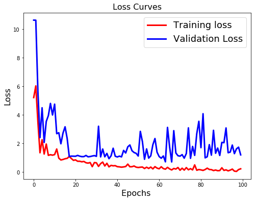

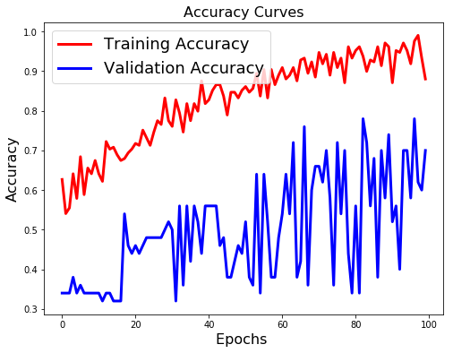

```python
import matplotlib.pyplot as plt

%matplotlib inline

def evaluate_model(model, x, y):
    score = model.evaluate(x, y)
    print('Loss value: {}'.format(score[0]))
    print('Accuracy: {}'.format(score[1]))


def plot_accuracy(history):
    # Loss Curves
    plt.figure(figsize=[8, 6])
    plt.plot(history.history['loss'], 'r', linewidth=3.0)
    plt.plot(history.history['val_loss'], 'b', linewidth=3.0)
    plt.legend(['Training loss', 'Validation Loss'], fontsize=18)
    plt.xlabel('Epochs ', fontsize=16)
    plt.ylabel('Loss', fontsize=16)
    plt.title('Loss Curves', fontsize=16)
    plt.show()

    # Accuracy Curves
    plt.figure(figsize=[8, 6])
    plt.plot(history.history['acc'], 'r', linewidth=3.0)
    plt.plot(history.history['val_acc'], 'b', linewidth=3.0)
    plt.legend(['Training Accuracy', 'Validation Accuracy'], fontsize=18)
    plt.xlabel('Epochs ', fontsize=16)
    plt.ylabel('Accuracy', fontsize=16)
    plt.title('Accuracy Curves', fontsize=16)
    plt.show()


evaluate_model(model, test_set_x, test_set_y)
plot_accuracy(hist_neural)
```

Olhando unicamente para os números, nossa perda no conjunto de validação foi de 1.21 e nossa acurácia foi de 0.70, o que não parece ser um valor ruim. No entanto, ao observar os gráficos plotados podemos tirar algumas conclusões mais precisas sobre a nossa rede.

Tanto no gráfico de perda quanto no de acurácia, as linhas do conjunto de treinamento e validação estão bastante distantes umas das outras. Além disso, no gráfico de perda podemos ver inicialmente uma queda no erro no conjunto de validação (até próximo da *epoch* 20) mas depois o erro se estabiliza e passa a ter picos de subida ao invés de seguir uma curva descendente como no conjunto de treinamento. Esses são indícios de que nossa rede está sofrente de *overfitting*, ou seja, o modelo "decorou" o conjunto de treinamento, mas não vai bem quando apresentamos dados não vistos antes por ele (durante o treinamento).

Uma forma de lidar com o *overfitting* pra nossa rede completamente conectada seria adicionar uma regularização a ela, que se daria através da adição de camadas de *dropout* à rede. No entanto, isso faria com que tivessemos que adicionais mais camadas a rede e deixaríamos de ter a arquitetura pedida pelo trabalho, portanto, manteremo-as como apresentada acima.

Agora vamos modelar e treinar nossa rede convolucional. Iremos realizar novamente o processo de leitura e pré-processamento dos dados. O de leitura para garantir que estamos trabalhando com o conjunto de dados base e o pré-processamento pois ele é diferente para a rede convolucional.

```python
# Leitura do conjunto de dados de treinamento
train_set_x, train_set_y, test_set_x, test_set_y, classes = load_dataset()
train_set_y = train_set_y.reshape(-1, 1)
test_set_y = test_set_y.reshape(-1, 1)
```

```python
def preprocessing_cnn(x, y):
    # Função para aplicar pré-processamento nos vetores
    # de features e target

    # Normalizando os valores de RGB para ficarem entre 0 e 1
    x_flatten = x.astype('float32')
    x_flatten = x_flatten/255

    # Transformando os valores inteiros de y em categorias
    # por ser o formato necessário para o Keras realizar a
    # classificação de múltiplas classes
    y_cat = to_categorical(y)

    return x_flatten, y_cat

# Aplicando pré-processamento nos vetores de features
train_set_x, train_set_y = preprocessing_cnn(train_set_x, train_set_y)
test_set_x, test_set_y = preprocessing_cnn(test_set_x, test_set_y)
print(train_set_x.shape)
print(train_set_y.shape)
input_shape = train_set_x[0].shape
print(input_shape)
```

```
(209, 64, 64, 3)
(209, 2)
(64, 64, 3)
```

Tendo os dados carregados e pré-processados, podemos modelar e treinar a rede convolucional. A processo de modelagem dela e de encontrar os hiperparâmetros que teriam um melhor resultado foi mais complexo por não ter sido dada indicação do formato da rede como foi feito para a rede completamente conectada. Mais uma vez, a abordagem utilizada foi a de buscar exemplos na internet que atacavam problemas semelhantes e, à partir deles, ir fazendo alterações na arquitetura até que fosse atingido um resultado satisfatório.

```python
from keras.layers import Dense, Conv2D, MaxPooling2D, Dropout, Flatten

def create_model_cnn(input_shape):
    model = Sequential()
    model.add(Conv2D(64, (3, 3), padding='same', activation='relu',
              input_shape=input_shape))
    model.add(MaxPooling2D(pool_size=(3, 3)))
    model.add(Dropout(0.25))

    model.add(Conv2D(128, (3, 3), padding='same', activation='relu'))
    model.add(MaxPooling2D(pool_size=(2, 2)))
    model.add(Dropout(0.25))

    model.add(Flatten())
    model.add(Dense(256, activation='relu'))
    model.add(Dropout(0.5))
    model.add(Dense(2, activation='softmax'))

    return model


def train_model_cnn(model, x_train, y_train, x_test, y_test, batch, epoch):
    model.compile(optimizer='sgd', loss='categorical_crossentropy',
                  metrics=['accuracy'])
    print(model.summary())
    history = model.fit(x_train, y_train, batch_size=batch, epochs=epoch,
                        validation_data=(x_test, y_test), shuffle=False)
    return history

# Criando o modelo de rede neural para predição
batch_size = 10
epochs = 100
model = create_model_cnn(input_shape)
hist_cnn = train_model_cnn(model, train_set_x, train_set_y,
                           test_set_x, test_set_y,
                           batch_size, epochs)
```

```
_________________________________________________________________
Layer (type)                 Output Shape              Param #
=================================================================
conv2d_1 (Conv2D)            (None, 64, 64, 64)        1792
_________________________________________________________________
max_pooling2d_1 (MaxPooling2 (None, 21, 21, 64)        0
_________________________________________________________________
dropout_1 (Dropout)          (None, 21, 21, 64)        0
_________________________________________________________________
conv2d_2 (Conv2D)            (None, 21, 21, 128)       73856
_________________________________________________________________
max_pooling2d_2 (MaxPooling2 (None, 10, 10, 128)       0
_________________________________________________________________
dropout_2 (Dropout)          (None, 10, 10, 128)       0
_________________________________________________________________
flatten_1 (Flatten)          (None, 12800)             0
_________________________________________________________________
dense_3 (Dense)              (None, 256)               3277056
_________________________________________________________________
dropout_3 (Dropout)          (None, 256)               0
_________________________________________________________________
dense_4 (Dense)              (None, 2)                 514
=================================================================
Total params: 3,353,218
Trainable params: 3,353,218
Non-trainable params: 0
_________________________________________________________________
None
Train on 209 samples, validate on 50 samples
```

A rede convolucional modelada possuí uma arquitetura de 10 camadas, dividas da seguinte forma:

- 2 camadas convolucionais de 2 dimensões
- 2 camadas de pooling (utiliando Max Pooling)
- 3 camadas de dropout
- 1 camada Flatten
- 2 camadas densas (completamente conectadas)

As camadas convolucionais são, como o próprio nome nos dá a entender, as principais camadas desse tipo de rede. Nessas camadas o que acontece, resumidamente, é um aprendizado de filtros por parte da rede, que irá percorrer a entrada que lhe for dada e irá "ativar" quando encontrar algum padrão que esteja de acordo com os filtros aprendidos.

Geralmente entre camadas convolucionais são adicionadas camada de pooling. Essas camadas tem como função a diminuição progressiva do tamanho espacial para que se tenham menos parâmetros e computações sendo processadas na rede. Outra utilidade dessa camada é o controle de *overfitting* que, como dito anteriormente, acontece quando uma rede "decora" os parâmetros em que foi treinada e não conseguir fazer uma generalização para um outro conjunto de dados que venha a ser apresentado a ela.

Outra maneira de combater o *overfitting* é através da adição de camadas de *dropout*. Nessas camadas algumas entradas são selecionados randômicamente para que sejam desligadas da rede, o que torna mais difícil que a rede que está sendo treinada fique totalmente aderente a um conjunto de treinamento.

A camada *Flatten* server para adequar os dados produzidos nas camadas de convolução para serem servidos para as camadas completamente conectadas, que são as responsáveis por produzir a classificação que será a saída do modelo. Ela funciona da mesma forma que numa rede completamente conectada, aonde temos que realizar essa operação com o mesmo objetivo.

Como dito anteriormente, tanto essa arquitetura quanto os parãmetros de cada camada foram descobertos à partir de modelos encontrados na internet que visavam resolver problemas de classificação semelhantes ao nosso. Foram feitos uma série de testes manuais com diferentes combinações de parâmetros em cada camada para chegar até o modelo final. Vamos ver qual foi o resultado desse modelo.

```
Loss value: 0.34498459339141846
Accuracy: 0.9399999904632569
```

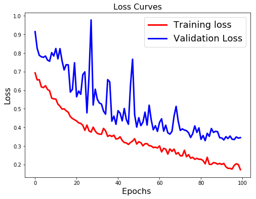

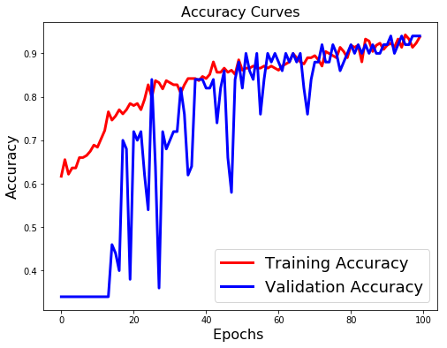

```python
evaluate_model(model, test_set_x, test_set_y)
plot_accuracy(hist_cnn)
```

A rede convolucional apresenta uma performance muito melhor do que a rede neural completamente conectada que treinamos na etapa anterior desse trabalho, atingindo uma perda de 0.34 e uma acurácia de praticamente 94%. Olhando para o gráfico da acurácia podemos ver que a rede generalizou bem, tendo desempenho muito semelhante no conjunto de treinamento e validação. No entanto, o gráfico de erro nos mostra uma certa distância entre os dois conjuntos de dados. Poderíamos tentar diminuir essa distância através de aplicações de técnicas como aumento dos dados (*data augmentation*), mas está fora do escopo desse trabalho.

## Referências

- Material da disciplina de Aprendizado de Máquina
- [Documentação do Keras](https://keras.io/)
- [CS231n - Convolutional Neural Networks for Visual Recognition](http://cs231n.stanford.edu/)
- [Learn OpenCV](https://www.learnopencv.com/)